# Reading Data: Standard Data Types

## Plan

- Go though examples of reading different types of data

| Type of file | Package | Function |
| --- | --- | --- |
| Delimited | `readr` | `read_csv()`, `read_tsv()`,`read_table()`, `read_delim(...,delim = ,...)` |
| Excel (.xls,.xlsx) | `readxl` | `read_excel` |
| SPSS (.sav) | `haven` | `read_spss` |
| SAS (.sas7bdat) | `haven` | `read_sas` |

- Write data with `write_csv()` from readr

## Reading in Data/Writing Out Data

**Reading in any delimited file**

- Read in umps.txt file (a ['>'](https://www4.stat.ncsu.edu/~post/ST558/datasets/umps2012.txt) delimited file)
- Notice no column names provided
  - Year Month Day Home Away HPUmpire
- Use `read_delim()` (check help!)

```r
umpData <- read_delim("https://www4.stat.ncsu.edu/~post/ST558/datasets/umps2012.txt",
                    delim = ">",
     col_names = c("Year", "Month", "Day", "Home", "Away", "HPUmpire")
)
```

## Reading in Data/Writing Out Data

```r
umpData
```

```
## # A tibble: 2,359 x 6
##    Year Month   Day Home  Away  HPUmpire
##   <int> <int> <int> <chr> <chr> <chr>
## 1  2012     4    12 MIN   LAA   D.J. Reyburn
## 2  2012     4    12 SD    ARI   Marty Foster
## 3  2012     4    12 WSH   CIN   Mike Everitt
## 4  2012     4    12 PHI   MIA   Jeff Nelson
## 5  2012     4    12 CHC   MIL   Fieldin Culbreth
## # ... with 2,354 more rows
```

## Reading in Data/Writing Out Data

**Reading in any delimited file**

- Functions from *readr* and their purpose

| Delimiter | Function |
| --- | --- |
| comma ',' | read_csv() |
| tab | read_tsv() |
| space ' ' | read_table() |
| semi-colon ';' | read_csv2() |
| other | read_delim(…,delim = ,…) |

## Reading in Data/Writing Out Data

**Fixed field data**

- Open the cigarettes.txt file: Read using `read_fwf()`
- Can specify columns in many ways

```r
#a guess based on reading a few columns
cigData <- read_fwf("https://www4.stat.ncsu.edu/~post/ST558/datasets/cigarettes.txt",
           col_positions =
            fwf_empty("https://www4.stat.ncsu.edu/~post/ST558/datasets/cigarettes.txt",
                 col_names = c("brand", "tar", "nicotine", "weight", "co"))
)
```

## Reading in Data/Writing Out Data

```r
cigData
```

```
## # A tibble: 24 x 5
##   brand       tar   nicotine weight co
##   <chr>       <chr> <chr>    <chr>  <chr>
## 1 brand       tar   nicotine weight "co\t"
## 2 Alpine      14.1  0.86     0.9853 13.6
## 3 Benson      16.0  1.06     1.0938 16.6
## 4 CamelLights 8.0   0.67     0.9280 10.2
## 5 Carlton     4.1   0.40     0.9462 5.4
## # ... with 19 more rows
```

## Reading in Data/Writing Out Data

**Fixed field data**

- Must skip first line!

```r
#need to skip first line!
cigData <- read_fwf("https://www4.stat.ncsu.edu/~post/ST558/datasets/cigarettes.txt",
           col_positions =
            fwf_empty("https://www4.stat.ncsu.edu/~post/ST558/datasets/cigarettes.txt",
                 col_names = c("brand", "tar", "nicotine", "weight", "co")),
       skip = 1
)
```

## Reading in Data/Writing Out Data

```r
cigData
```

```
## # A tibble: 23 x 5
##   brand          tar nicotine weight    co
##   <chr>        <dbl>    <dbl>  <dbl> <dbl>
## 1 Alpine        14.1     0.86  0.985  13.6
## 2 Benson        16       1.06  1.09   16.6
## 3 CamelLights    8       0.67  0.928  10.2
## 4 Carlton        4.1     0.4   0.946   5.4
## 5 Chesterfield  15       1.04  0.888  15
## # ... with 18 more rows
```

## Reading in Data/Writing Out Data

**Fixed field data**

- Can specify columns in many ways

```r
#another option
cigData<-read_fwf("https://www4.stat.ncsu.edu/~post/ST558/datasets/cigarettes.txt",
              col_positions = fwf_widths(c(17, 5, 9, 6, NA),
                col_names = c("brand", "tar", "nicotine", "weight", "co")),
                    skip = 1
  )
```

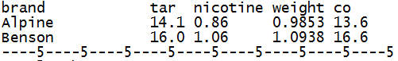

## Reading in Data/Writing Out Data

**Other useful functions for tricky data**

- read_file()
  - reads an entire file into a single string
- read_lines()
  - reads a file into a character vector with one element per line
- Usually parse with `regular expressions`

## Reading in Data/Writing Out Data

**Excel Data**

- Read in [censusEd.xls](https://www4.stat.ncsu.edu/~post/ST558/datasets/censusEd.xlsx)
- Using `read_excel()` from `readxl` package
  - Reads both xls and xlsx files
  - Detects format from extension given
  - Specify sheet with name or integers (or NULL for 1st)

```r
library(readxl)
#just first sheet
edData <- read_excel("../datasets/censusEd.xlsx", sheet = "EDU01A")
```

## Reading in Data/Writing Out Data

```r
edData
```

```
## # A tibble: 3,198 x 42
##   Area_name STCOU EDU010187F EDU010187D EDU010187N1 EDU010187N2 EDU010188F
##   <chr>     <chr>      <dbl>      <dbl> <chr>       <chr>            <dbl>
## 1 UNITED S~ 00000          0   40024299 0000        0000                 0
## 2 ALABAMA   01000          0     733735 0000        0000                 0
## 3 Autauga,~ 01001          0       6829 0000        0000                 0
## 4 Baldwin,~ 01003          0      16417 0000        0000                 0
## 5 Barbour,~ 01005          0       5071 0000        0000                 0
## # ... with 3,193 more rows, and 35 more variables: EDU010188D <dbl>,
## #   EDU010188N1 <chr>, EDU010188N2 <chr>, EDU010189F <dbl>,
## #   EDU010189D <dbl>, EDU010189N1 <chr>, EDU010189N2 <chr>,
## #   EDU010190F <dbl>, EDU010190D <dbl>, EDU010190N1 <chr>,
## #   EDU010190N2 <chr>, EDU010191F <dbl>, EDU010191D <dbl>,
## #   EDU010191N1 <chr>, EDU010191N2 <chr>, EDU010192F <dbl>,
## #   EDU010192D <dbl>, EDU010192N1 <chr>, EDU010192N2 <chr>,
## #   EDU010193F <dbl>, EDU010193D <dbl>, EDU010193N1 <chr>,
## #   EDU010193N2 <chr>, EDU010194F <dbl>, EDU010194D <dbl>,
## #   EDU010194N1 <chr>, EDU010194N2 <chr>, EDU010195F <dbl>,
## #   EDU010195D <dbl>, EDU010195N1 <chr>, EDU010195N2 <chr>,
## #   EDU010196F <dbl>, EDU010196D <dbl>, EDU010196N1 <chr>,
## #   EDU010196N2 <chr>
```

## Reading in Data/Writing Out Data

**Excel Data**

- Using `read_excel()` from `readxl` package
  - Specify sheet with name or integers (or `NULL` for 1st)
  - Look at sheets available

```r
excel_sheets("../datasets/censusEd.xlsx")
```

```
##  [1] "EDU01A" "EDU01B" "EDU01C" "EDU01D" "EDU01E" "EDU01F" "EDU01G"
##  [8] "EDU01H" "EDU01I" "EDU01J"
```

## Reading in Data/Writing Out Data

**Excel Data**

- Using `read_excel()` from `readxl` package
  - Specify cells with contiguous range

```r
library(readxl)
#just first sheet
edData <- read_excel("../datasets/censusEd.xlsx", sheet = "EDU01A",
                   range = cell_cols("A:D")
                   )
```

## Reading in Data/Writing Out Data

```r
edData
```

```
## # A tibble: 3,198 x 4
##   Area_name     STCOU EDU010187F EDU010187D
##   <chr>         <chr>      <dbl>      <dbl>
## 1 UNITED STATES 00000          0   40024299
## 2 ALABAMA       01000          0     733735
## 3 Autauga, AL   01001          0       6829
## 4 Baldwin, AL   01003          0      16417
## 5 Barbour, AL   01005          0       5071
## # ... with 3,193 more rows
```

## Reading in Data/Writing Out Data

**SPSS Data**

- SPSS data has extension ".sav"
- Read in bodyFat.sav
- Use `read_spss()` from `haven` package
- Not many options!

```r
library(haven)
bodyFatData <- read_spss("https://www4.stat.ncsu.edu/~post/ST558/datasets/bodyFat.sav")
```

## Reading in Data/Writing Out Data

```r
bodyFatData
```

```
## # A tibble: 20 x 4
##        y    x1    x2    x3
##    <dbl> <dbl> <dbl> <dbl>
##  1  19.5  43.1  29.1  11.9
##  2  24.7  49.8  28.2  22.8
##  3  30.7  51.9  37    18.7
##  4  29.8  54.3  31.1  20.1
##  5  19.1  42.2  30.9  12.9
##  6  25.6  53.9  23.7  21.7
##  7  31.4  58.5  27.6  27.1
##  8  27.9  52.1  30.6  25.4
##  9  22.1  49.9  23.2  21.3
## 10  25.5  53.5  24.8  19.3
## 11  31.1  56.6  30    25.4
## 12  30.4  56.7  28.3  27.2
## 13  18.7  46.5  23    11.7
## 14  19.7  44.2  28.6  17.8
## 15  14.6  42.7  21.3  12.8
## 16  29.5  54.4  30.1  23.9
## 17  27.7  55.3  25.7  22.6
## 18  30.2  58.6  24.6  25.4
## 19  22.7  48.2  27.1  14.8
## 20  25.2  51    27.5  21.1
```

## Reading in Data/Writing Out Data

**SAS Data**

- SAS data has extension '.sas7bdat'
- Read in smoke2003.sas7bdat
- Use `read_sas()` from haven package
- Not many options!

```r
smokeData <- read_sas("https://www4.stat.ncsu.edu/~post/ST558/datasets/smoke2003.sas7bdat")
```

## Reading in Data/Writing Out Data

```r
smokeData
```

```
## # A tibble: 443 x 54
##    SEQN SDDSRVYR RIDSTATR RIDEXMON RIAGENDR RIDAGEYR RIDAGEMN RIDAGEEX
##   <dbl>    <dbl>    <dbl>    <dbl>    <dbl>    <dbl>    <dbl>    <dbl>
## 1 21010        3        2        2        2       52      633      634
## 2 21012        3        2        2        1       63      765      766
## 3 21048        3        2        1        2       42      504      504
## 4 21084        3        2        1        2       57      692      693
## 5 21093        3        2        1        2       64      778      778
## # ... with 438 more rows, and 46 more variables: RIDRETH1 <dbl>,
## #   RIDRETH2 <dbl>, DMQMILIT <dbl>, DMDBORN <dbl>, DMDCITZN <dbl>,
## #   DMDYRSUS <dbl>, DMDEDUC3 <dbl>, DMDEDUC2 <dbl>, DMDEDUC <dbl>,
## #   DMDSCHOL <dbl>, DMDMARTL <dbl>, DMDHHSIZ <dbl>, INDHHINC <dbl>,
## #   INDFMINC <dbl>, INDFMPIR <dbl>, RIDEXPRG <dbl>, DMDHRGND <dbl>,
## #   DMDHRAGE <dbl>, DMDHRBRN <dbl>, DMDHREDU <dbl>, DMDHRMAR <dbl>,
## #   DMDHSEDU <dbl>, SIALANG <dbl>, SIAPROXY <dbl>, SIAINTRP <dbl>,
## #   FIALANG <dbl>, FIAPROXY <dbl>, FIAINTRP <dbl>, MIALANG <dbl>,
## #   MIAPROXY <dbl>, MIAINTRP <dbl>, AIALANG <dbl>, WTINT2YR <dbl>,
## #   WTMEC2YR <dbl>, SDMVPSU <dbl>, SDMVSTRA <dbl>, Gender <dbl>,
## #   Age <dbl>, IncomeGroup <chr>, Ethnicity <chr>, Education <dbl>,
## #   SMD070 <dbl>, SMQ077 <dbl>, SMD650 <dbl>, PacksPerDay <dbl>,
## #   lbdvid <dbl>
```

## Reading in Data/Writing Out Data

**SAS Data**

- Note: Variables had SAS labels. Don't show on print!
  - Will show on View(smokeData) (or click on data from environment)

```r
str(smokeData)
```

```
## Classes 'tbl_df', 'tbl' and 'data.frame':    443 obs. of  54 variables:
##  $ SEQN       : num  21010 21012 21048 21084 21093 ...
##   ..- attr(*, "label")= chr "Patient ID"
##  $ SDDSRVYR   : num  3 3 3 3 3 3 3 3 3 3 ...
##   ..- attr(*, "label")= chr "Data Release Number"
##  $ RIDSTATR   : num  2 2 2 2 2 2 2 2 2 2 ...
##   ..- attr(*, "label")= chr "Interview/Examination Status"
##  $ RIDEXMON   : num  2 2 1 1 1 2 1 2 1 1 ...
##   ..- attr(*, "label")= chr "Six month time period"
##  $ RIAGENDR   : num  2 1 2 2 2 2 1 2 1 2 ...
##   ..- attr(*, "label")= chr "Gender 1=M 2=F"
##  $ RIDAGEYR   : num  52 63 42 57 64 63 66 60 65 47 ...
##   ..- attr(*, "label")= chr "Age in Years at Exam"
##  $ RIDAGEMN   : num  633 765 504 692 778 763 801 731 786 573 ...
##   ..- attr(*, "label")= chr "Age in Months - Recode"
##  $ RIDAGEEX   : num  634 766 504 693 778 763 801 732 787 573 ...
##   ..- attr(*, "label")= chr "Exam Age in Months - Recode"
##  $ RIDRETH1   : num  3 4 1 3 2 3 1 3 3 3 ...
##   ..- attr(*, "label")= chr " Ethnicity 1=MexAm 2=OthHisp 3=OthCauc 4=OthBla 5=Oth"
##  $ RIDRETH2   : num  1 2 3 1 5 1 3 1 1 1 ...
##   ..- attr(*, "label")= chr "Linked NH3 Race/Ethnicity - Recode"
##  $ DMQMILIT   : num  2 2 2 2 2 2 2 2 1 2 ...
##   ..- attr(*, "label")= chr "Veteran/Military Status"
##  $ DMDBORN    : num  1 1 1 1 3 1 1 1 1 1 ...
##   ..- attr(*, "label")= chr "Country of Birth - Recode"
##  $ DMDCITZN   : num  1 1 1 1 1 1 1 1 1 1 ...
##   ..- attr(*, "label")= chr "Citizenship Status"
##  $ DMDYRSUS   : num  NA NA NA NA 9 NA NA NA NA NA ...
##   ..- attr(*, "label")= chr "Length of time in US"
##  $ DMDEDUC3   : num  NA NA NA NA NA NA NA NA NA NA ...
##   ..- attr(*, "label")= chr "Education Level - Children/Youth 6-19"
##  $ DMDEDUC2   : num  4 3 3 4 1 3 1 4 4 4 ...
##   ..- attr(*, "label")= chr "Education Level for Over 20"
##  $ DMDEDUC    : num  3 2 2 3 1 2 1 3 3 3 ...
##   ..- attr(*, "label")= chr "Education - Recode (old version)"
##  $ DMDSCHOL   : num  NA NA NA NA NA NA NA NA NA NA ...
##   ..- attr(*, "label")= chr "Now attending school?"
##  $ DMDMARTL   : num  6 6 3 1 2 1 6 3 1 1 ...
##   ..- attr(*, "label")= chr "Marital Status"
##  $ DMDHHSIZ   : num  3 2 5 2 2 2 2 3 2 6 ...
```

[output cut: 48 more lines]

```
##   ..- attr(*, "label")= chr "Masked Variance Pseudo-Stratum"
##  $ Gender     : num  2 1 2 2 2 2 1 2 1 2 ...
##  $ Age        : num  52 63 42 57 64 63 66 60 65 47 ...
##  $ IncomeGroup: chr  "Less Than 20K" "Less Than 20K" "Less Than 20K" "More Than 20K" ...
##  $ Ethnicity  : chr  "Non-Hispanic Caucasian" "Non-Hispanic Black" "MexicanAmerican & Hispanic" "Non-Hispanic Caucasian" ...
##  $ Education  : num  4 3 3 4 1 3 1 4 4 4 ...
##  $ SMD070     : num  20 20 20 20 20 16 20 20 10 6 ...
##   ..- attr(*, "label")= chr "Number of Cagarettes Smoked/day now"
##  $ SMQ077     : num  2 2 1 3 2 2 2 1 3 3 ...
##   ..- attr(*, "label")= chr "How soon after waking do you smoke?"
##  $ SMD650     : num  20 20 20 20 20 10 20 20 10 1 ...
##   ..- attr(*, "label")= chr "Number of Cigarettes/day for last 30 days"
##  $ PacksPerDay: num  1 1 1 1 1 0.5 1 1 0.5 0.05 ...
##  $ lbdvid     : num  16 18 16 17 18 25 9 27 9 25 ...
##  - attr(*, "label")= chr "DATA2003"
```

## Reading in Data/Writing Out Data

**SAS Data**

- Note: Variables had SAS labels. Don't show on print!
  - Will show on View(smokeData) (or click on data from environment)
  - Can access via

```r
attr(smokeData$SDDSRVYR, "label")
```

```
## [1] "Data Release Number"
```

## Reading in Data/Writing Out Data

**Writing Data**

- Usually write to .csv (or other delimiter)
- Use `write_csv()` from `readr` package
- Check help!
  - Will write to path or working directory

```r
write_csv(x = smokeData,
          path = "output/smokeData.csv")
```

## Reading in Data/Writing Out Data

**Writing Data**

- Usually write to .csv (or other delimiter)
- Use `write_csv()` from `readr` package
- Check help!
  - Will write to path or working directory
  - `append` option won't overwrite but structures must match…

```r
write_csv(x = bodyFatData,
          path = "output/smokeData.csv",
          append = TRUE)
```

## Recap

- Reading Data

| Type of file | Package | Function |
| --- | --- | --- |
| Delimited | `readr` | `read_csv()`, `read_tsv()`,`read_table()`, `read_delim(...,delim = ,...)` |
| Excel (.xls,.xlsx) | `readxl` | `read_excel` |
| SPSS (.sav) | `haven` | `read_spss` |
| SAS (.sas7bdat) | `haven` | `read_sas` |

- Write data with `write_csv()` from readr